# Finančni zakup (lizing) vozil

Anže Marinko

julij 2015

Sem Anže Marinko, študent 3. letnika finančne matematike na Fakulteti za matematiko in fiziko na Univerzi v Ljubljani. V tem potočilu bom predstavil svoje rezultate napovedovanja tveganja finančnega zakupa (lizing) vozil. Seminarsko nalogo sem naredil v okviru predmeta Izbrane teme iz analize podatkov.

## Podatkovna množica

Učna podatkovna množica vsebuje 6.062 predmetov zakupa (leasinga) vozil, ki jih je leta 2015 obravnavalo izbrano leasing podjetje v Sloveniji. Vsak predmet je opisan z 31 spremenljivkami, ki se nanašajo na lastnosti stranke, njenega delodajalca, leasing predmeta, vozila in njegovega dobavitelja. Ciljna spremenljivka je *Lodobren*.

### Transformacija podatkov

Uvozil sem učne in testne podatke, jih normaliziral po stolpcih (tu pride do polnadzorovanega učenja) in ugotovil, da podatki manjkajo pri *Splacilni_indeks* in *Szapadlo_neplacano*, kjer manjka 60% podatkov (enako tudi pri testnih podatkih). Ker pa so v obeh stolpcih manjkajoči podatki na istih mestih, sem dodal le en stolpec z enicami na tistih mestih in ničlami sicer, manjkajoče podatke pa sem nadomestil s povprečjem stolpca.

Nato sem namesto diskretnih spremenljivk dodal naivne spremenljivke (spremenljivka *Vznamka* je imela sprva 48 možnosti), spremenljivke z majhno varianco sem odstranil (veliko znamk vozil je imelo namreč le po nekaj pojavitev v stolpcu *Vznamka*).

Oglejmo si nekaj izbranih primerov pri nekaj izbranih spremenljivkah (numerične spremenljivke so normalizirane in pomnožene s 1000):

```
##     VznamkaBMW VznamkaCITROEN VznamkaPEUGEOT   Dstpogodb Snetoplaca
##  1:          0              0              0   8.1309807  12.318548
##  2:          0              0              0  87.7814038   7.933370
##  3:          0              0              0  25.9417003  10.080351
##  4:          0              0              0 437.6901377  10.818289
##  5:          0              0              0 188.5060014  11.587306
##  6:          0              0              0  89.3854749   7.735272
##  7:          0              0              1   3.3187676   5.853221
##  8:          0              0              0  17.3682173   7.939181
##  9:          0              1              0   1.2168815   7.753086
## 10:          0              0              0   0.5531279  15.918538
##     Sstarost SdrzavljanstvoSLOVENIA Lodobren
##  1: 426.8293                      1        1
##  2: 390.2439                      1        1
##  3: 597.5610                      1        1
##  4: 475.6098                      1        1
##  5: 219.5122                      1        1
##  6: 353.6585                      1        0
##  7: 219.5122                      1        0
##  8: 353.6585                      1        0
##  9: 207.3171                      1        0
## 10: 219.5122                      1        0
```

## Grajenje modelov

Zgradil sem več modelov, ki sem jih ocenjeval tako, da sem napaki druge stopnje dal dvojno težo, torej sem minimiziral *FN / (TP + FN) + 2 x FP / (TN + FP)*, saj se mi zdi sklenjena slaba pogodba v tem primeru slabša od nesklenjene dobre. (*T*-true, *F*-false, *P*-positive, *N*-negative)

Modele sem treniral s sedemkratnim prečnim preverjanjem.

### Modeli

Oglejmo si cene napak za nekaj modelov:

#### SVM

*Tu sem zaradi časovne zahtevnosti opravil le pet prečnih preverjanj.*

```
##              C      cost     costSD
## 1 4.978707e-02 0.9365094 0.06597840
## 2 1.484132e+02 0.9545232 0.01851313
## 3 1.627548e+05 0.9241828 0.05205823
## 4 3.269017e+06 1.1342728 0.26486996
## 5 6.565997e+07 1.3063137 0.11833743
```

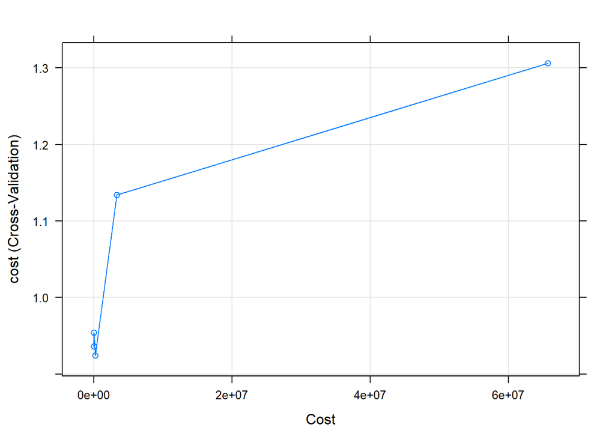

#### Random Forest

```
##   mtry      cost     costSD
## 1   10 0.4043573 0.04189301
## 2   15 0.4089557 0.03356739
## 3   20 0.4246108 0.02908247
```

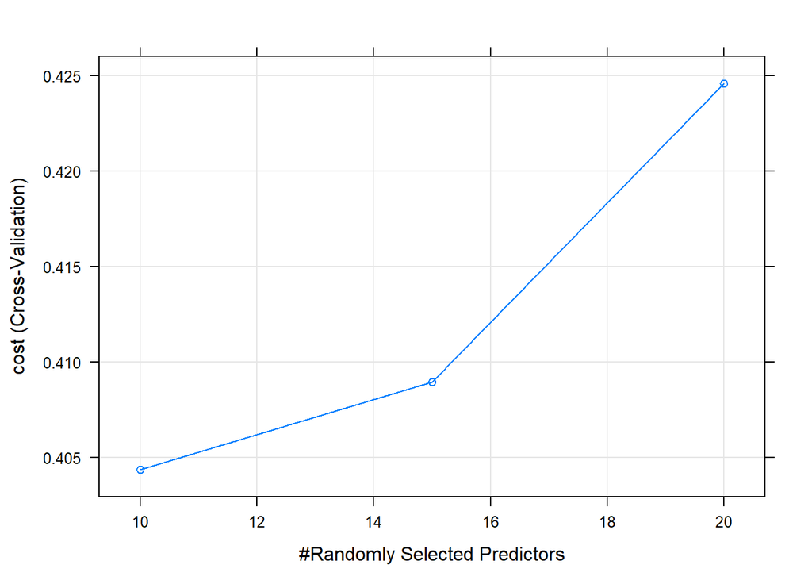

#### KNN

```
##   k     cost     costSD
## 1 2 1.041305 0.05137111
## 2 3 1.051688 0.06682726
## 3 4 1.096494 0.05575329
## 4 5 1.073572 0.04241381
## 5 6 1.095745 0.04757184
## 6 7 1.100350 0.05236057
## 7 8 1.143704 0.03839198
```

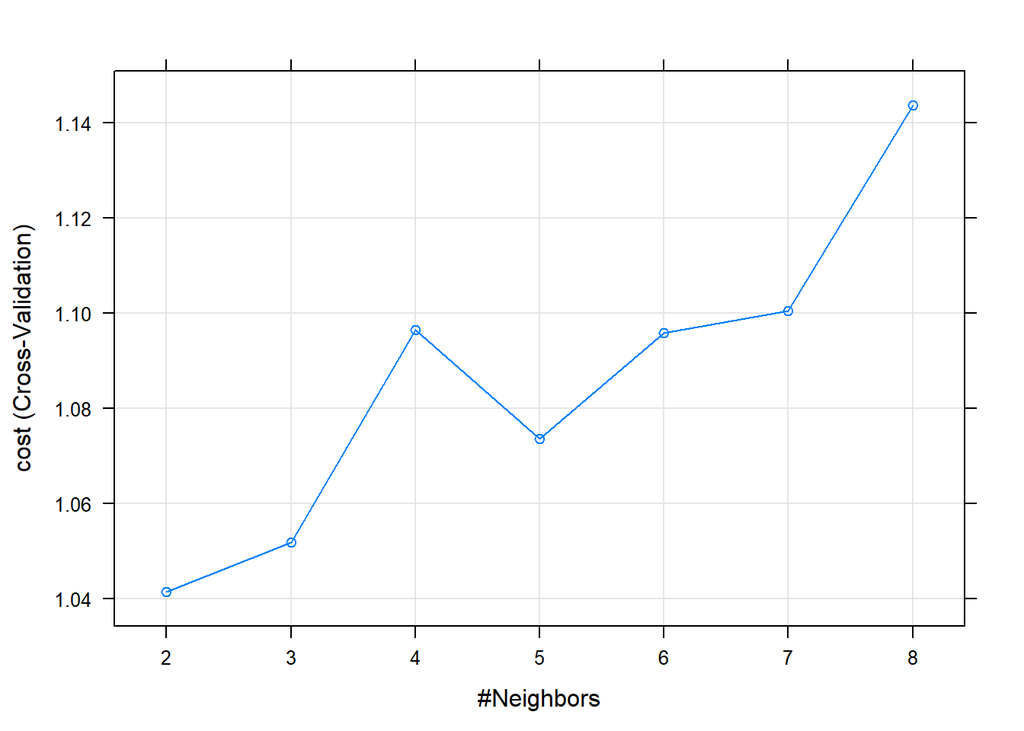

#### GLM

```
##   parameter      cost     costSD
## 1      none 0.8375498 0.04085894
```

### Predstavitev in napovedi končnega modela

Glede na to mero je očitno najboljši model *random forest*, ki sem ga naučil na 200 drevesih z 10, 15 in 20 ponavljanji. Napovedi zakupov za testno množico so v naslednjem razmerju:

```
##  Lodobren
##  NE:701
##  DA:815
```